# IE 360 HW1.R

halittasdemir

2022-04-13

HALİT TAŞDEMİR IE 360 HW 1 2022-04-13 1-INTRODUCTION

I wanted to see the effect of USD/TRY exchange rates on cost of living indices for wage earners for clothing (ICC 1995=100), consumer price index for clothing, and overall google search for “Giyim”. I wanted to question how the increase in USD/TRY exchange rates affected customers’ access to clothes and how much these datas are correlated.

USED PACKAGES

```r
install.packages("openxlsx",repos="http://cran.us.r-project.org")
```

```r
library(openxlsx)
install.packages("corrplot",repos="http://cran.us.r-project.org")
```

```
##
##   There is a binary version available but the source version is later:
##          binary source needs_compilation
## corrplot   0.89   0.92             FALSE
```

```
## installing the source package 'corrplot'
```

```r
library(corrplot)
install.packages("rmarkdown",repos="http://cran.us.r-project.org")
library(rmarkdown)
```

GETTING THE DATA

```r
hw_data <- read.xlsx("EVDS-2.xlsx")
giyimgoogle <- read.csv(file="giyimgoogle.csv")
```

GENERAL SUMMMARY

```r
summary(hw_data[,2])
```

```
##    Min. 1st Qu.  Median    Mean 3rd Qu.    Max.
##   1.418   1.805   2.917   3.889   5.660  14.566
```

USD/TRY

```r
summary(hw_data[,3])
```

```
##    Min. 1st Qu.  Median    Mean 3rd Qu.    Max.
##   105.2   142.1   175.8   185.2   224.1   309.5
```

cost of living indices for wage earners for clothing (ICC 1995=100)

```r
summary(hw_data[,4])
```

```
##    Min. 1st Qu.  Median    Mean 3rd Qu.    Max.
##    4136    6315    7730    8555   11119   16232
```

CPI for clothing

```r
summary(giyimgoogle)
```

```
##        G1
##  Min.   : 34.00
##  1st Qu.: 50.00
##  Median : 56.00
##  Mean   : 57.99
##  3rd Qu.: 66.00
##  Max.   :100.00
```

Google Trends Data for “giyim”

```r
head(hw_data[,2])
```

```
## [1] 1.462138 1.480021 1.499513 1.466320 1.505560 1.528313
```

```r
tail(hw_data[,2])
```

```
## [1]  9.139945 10.523264 13.528496 13.519262 13.621125 14.565609
```

head and tail of USD/TRY

```r
head(hw_data[,3])
```

```
## [1] 118.82 124.76 121.25 111.21 105.21 105.44
```

```r
tail(hw_data[,3])
```

```
## [1] 282.21 286.17 309.09 306.05 305.23 309.52
```

head and tail of cost of living indices

```r
head(hw_data[,4])
```

```
## [1] 5353.0 5322.7 5267.7 4784.3 4136.0 4270.7
```

```r
tail(hw_data[,4])
```

```
## [1] 15503.3 15866.8 15963.6 15902.0 15597.6 16231.7
```

head and tail of CPI for clothing

```r
head(giyimgoogle)
```

```
##         G1
## 2009-10 57
## 2009-11 63
## 2009-12 61
## 2010-01 63
## 2010-02 65
## 2010-03 65
```

```r
tail(giyimgoogle)
```

```
##         G1
## 2021-10 43
## 2021-11 38
## 2021-12 34
## 2022-01 35
## 2022-02 37
## 2022-03 40
```

PLOTS

USD/TRY

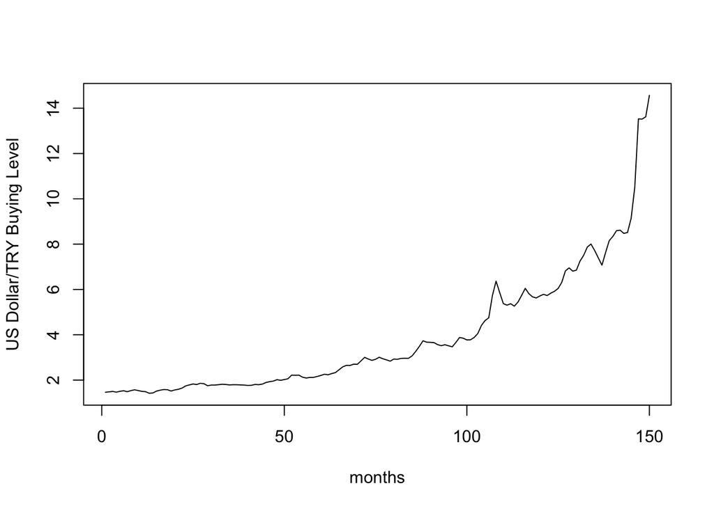

```r
plot(1:150, hw_data[,2], type="l", xlab="months", ylab="US Dollar/TRY Buying Level")
```

COST OF LIVING

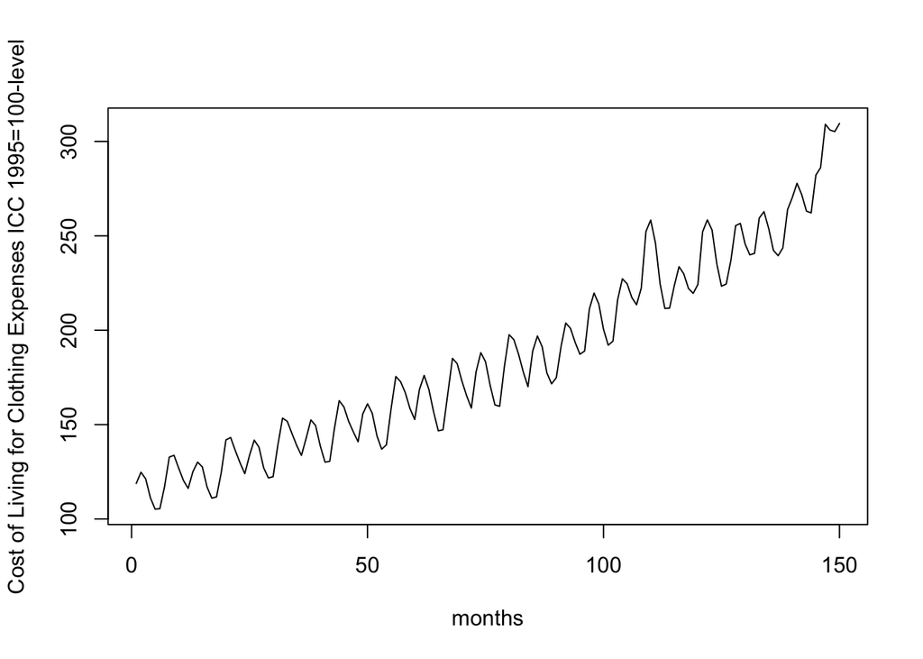

```r
plot(1:150, hw_data[,3], type="l", xlab="months", ylab="Cost of Living for Clothing Expenses ICC 1995=100-level")
```

CPI

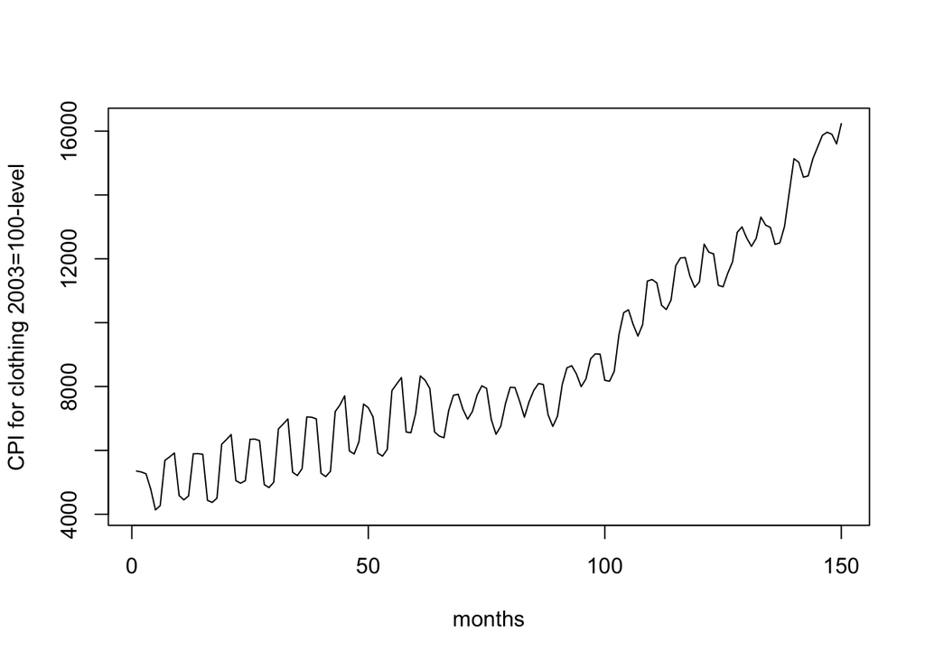

```r
plot(1:150, hw_data[,4], type="l", xlab="months", ylab="CPI for clothing 2003=100-level")
```

GOOGLE SEARCH OF “giyim”

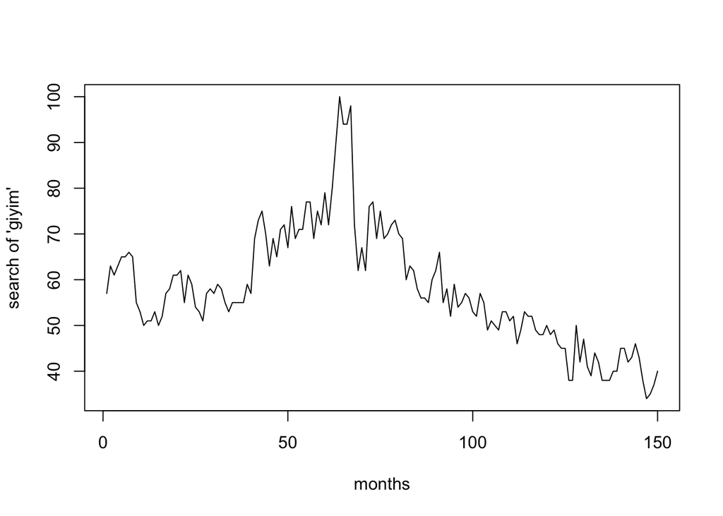

```r
plot(1:150, giyimgoogle[,1], type="l", xlab="months", ylab="search of 'giyim'")
```

CORRELATION MATRIX

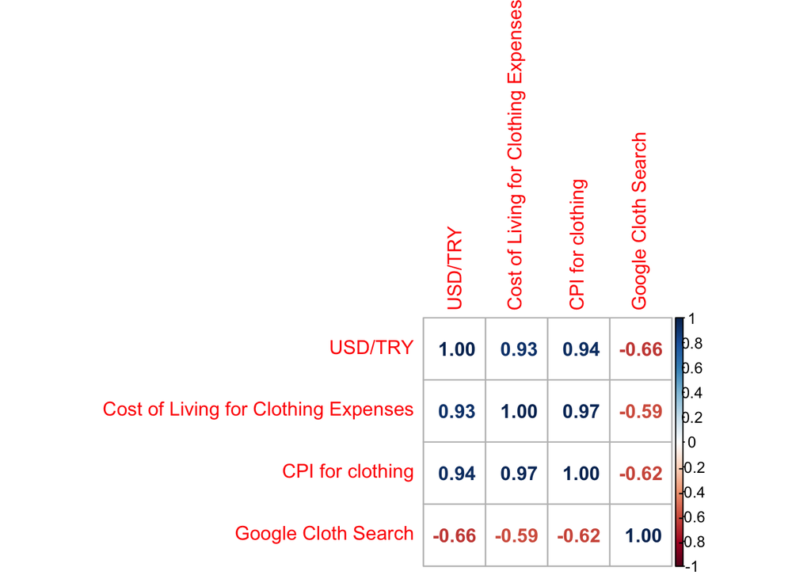

```r
data <- data.frame( hw_data[,2],  hw_data[,3], hw_data[,4], giyimgoogle)
names(data) <- c("USD/TRY", "Cost of Living for Clothing Expenses", "CPI for clothing" , "Google Cloth Search")
data_correlation = cor(data)
corrplot(data_correlation, method="number")
```

CONCLUSION

I wanted to learn how USD/TRY rates going up affected the clothing sector. At first I plotted the graphs and the correlation could be easily seen by simply looking. After that, I decided to make a correlation matrix. As can be seen in the correlation matrix, USD/TRY, Cost of living for clothing and CPI are highly correlated, whereas people’s search of “giyim” also decreased since it gets harder to afford clothes.